# Introduction to R for Biologists

Maria Doyle, Jessica Chung, Vicky Perreau, Kim-Anh Lê Cao, Saritha Kodikara, Eva Hamrud

20 January 2026

# R for Biologists course

R takes time to learn, like a spoken language. No one can expect to be an R expert after learning R for a few hours. This course has been designed to introduce biologists to R, showing some basics, and also some powerful things R can do (things that would be more difficult to do with Excel). The aim is to give beginners the confidence to continue learning R, so the focus here is on tidyverse and visualisation of biological data, as we believe this is a productive and engaging way to start learning R. After this short introduction you can read [this book](https://bookdown.org/ansellbr/WEHI_tidyR_course_book) to dive a bit deeper.

Most R programmers do not remember all the command lines we share in this document. R is a language that is continuously evolving. They use Google extensively to use many new tricks. Do not hesitate to do the same!

# 1. Intro to R and RStudio

RStudio is an interface that makes it easier to use R. There are four windows in RStudio. The screenshot below shows an [analogy linking the different RStudio windows to cooking](https://twitter.com/RLadiesNCL/status/1138812826917724160).

[figure not shown]

## R script vs console

There are two ways to work in RStudio in the console or in a script.

Let’s start by running a command in the console.

**Your turn 1.1:** Run the command below in the console.

```r
1 + 1
```

Once you’ve typed in the command into your console, just press enter. The output should be printed into the console.

Alternatively, we can use an R script. An R script allows us to have a record (recipe) of what we have done, whilst commands we type into the console are not saved. Keeping a record speeds up our analysis because we can re-use code, its also helpful to remember what we have done before!

**Your turn 1.2:** Create a script from the top menu in RStudio: `File > New File > R Script`, then type the command below in your new script.

```r
2 + 2
```

To run a command in a script, we place the cursor on the line you want to run, and then either:

- Click on the `run` button on top of the panel
- Use `Ctrl` + `Enter` (Windows/Linux) or `Cmd` + `Enter` (MacOS).

You can also highlight multiple lines at once and run them at once - have a go!

**✔️ Recommended Practice: Use Scripts**  
The console is great for quick tests or running single lines of code. However, for more complex analyses, using scripts is best practice. Scripts help keep your work organized and reproducible. We’ll use scripts for the rest of this workshop.

## Commenting

Comments are notes to ourself or others about the commands in the script. They are useful also when you share code with others. Comments start with a `#` which tells R not to run them as commands.

```r
# testing R
2 + 2
```

Keeping an accurate record of how you have manipulated your data is important for [reproducible research](https://ropensci-archive.github.io/reproducibility-guide/). Writing detailed comments and documenting your work are useful reminders to your future self (and anyone else reading your scripts) on what your code does.

Commenting code is good practice, why not try commenting on the code you write in this session to get into the habit, it will also male your R script more informative when you come back to it in the future.

## Working directory

Opening an RStudio session launches it from a specific location. This is the ‘working directory’.

**ⓘ Understanding the Working Directory**  
The working directory is the folder where R reads and saves files on your computer. When working in R, you’ll often read data files and write outputs like analysis results or plots. Knowing where your working directory is set helps ensure R finds your files and saves outputs in the right place.

You can find out where the working directory is set to by using two different approaches:

- Run the command `getwd()`. This will print out the path to your working directory in the console. It will be in this format: `/path/to/working/directory` (Mac) or `C:\path\to\working\directory` (Windows).
- Click the `cog icon/More > Go To Working Directory` in the menu at the top of the bottom right panel. This will show you the location and files in your working directory in the files window.

**Your turn 1.3:** Where is you working directory set to at the moment? Is this a useful place to have it set?

By default the working directory is often your home directory. To keep data and scripts organised its good practice to set your working directory as a specific folder.

**Your turn 1.4:** Create a folder for this course somewhere on your computer. Name the folder for example, `Intro_R_course`. Then, to set this folder as your working directory, you can do this in multiple ways, e.g.:

- Click in the menu at the top on `Session > Set Working Directory > Choose directory` and choose your folder
- In the bottom right panel, navigate to the folder that you want to be your working directory. Then click in the menu in the bottom right panel `cog icon/More > Set As Working Directory`

You will see that once you have set your working directory, the files inside your new folder will appear in the ‘Files’ window on RStudio.

**Your turn 1.5:** Save the script you created in the previous section as `intro.R` in this directory. You can do this by clicking on `File > Save` and the default location should be the current working directory (e.g. `Intro_R_course`).

**🔧 Multiple Ways to Achieve the Same Goal in R**  
You might have noticed by now that in R, there are often several ways to accomplish the same task. You might find one method more intuitive or easier to use than others — and that’s okay! Experiment, explore, and choose the approach that works best for you.

You might have noticed that when you set your working directory in the previous step, a line appeared in your console saying something like `setwd("~/Desktop/Intro_R_course")`. As well as the point-and-click methods described above, you can also set your working directory using the `setwd()` command in the console or in a script.

**Your turn 1.6:** What might be an advantage of using the command line option (`setwd`) instead of point-and-click to set your working directory?

## Functions

In mathematics, a function defines a relation between inputs and output. In R (and other coding languages) it is the same. A function (also called a command) takes inputs called *arguments* inside parentheses, and output some results.

We have actually already used two functions in this workshop - `getwd()` and `setwd()`. `getwd()` does not take an input, but outputs your working directory. `setwd()` takes a path as its input, and sets it as your working directory.

Let’s take a look at some more functions below.

**Your turn 1.7:** Compare these two outputs. In the second line we use the function `sum()`.

```r
2+2
sum(2,2)
```

**Your turn 1.8:** Try using the below function with different inputs, what does it do?

```r
sqrt(9)
sqrt(81)
```

## Objects

It is useful to store data or result so that we can use them later on for other parts of the analysis. To do this, we turn the data into an **object** (also called a variable). We can use either the operator `=` or `<-` to do this. In both cases the object where we store the result is on the left-hand-side, and the result from the operation is on the right-hand-side.

For example, the below code assigns the number `5` to the object `X` using the `=` operator. You can print out what the `X` object is by just typing it into the console or running it in your script.

**Your turn 1.9:** Make an object called `X` and print it.

```r
X = 5
X
```

As described above, you can assign objects using eith the `=` or `<-` operator.

**Your turn 1.10:** Compare the two outputs.

```r
result1 = 2+2
result1

result2 <- 2+3
result2
```

Once you have assigned objects, you can perform manipulations on them using functions.

**Your turn 1.11:** Compare the two outputs.

```r
sum(1,2)

X <- 1
Y <- 2
sum(X,Y)
```

Remember, if you use the same object name multiple times, R will overwrite the previous object you had created.

**Your turn 1.12:** What is the value of X after running this code?

```r
X <- 5
X <- 10
```

**Your turn 1.13:** Can you write code to calculate the sum of the square root of 9 and 16?

**✔️ Recommended Practice: Name your objects with care**

Use clear and descriptive names for your objects, such as `data_raw` and `data_normalised`, instead of vague names like `data1` and `data2`. This makes it easier to track different steps in your analysis.

So far we have looked at objects which are numbers. However objects can also be made of characters, these are called *strings*. To create a string you need to use speech marks `""`. Note that you can either use `print()` to print out your object, or just run the object name directly.

```r
my_string <- "Hello!"
print(my_string)
```

```
## [1] "Hello!"
```

There are a whole host of different objects you can make in R, too many to cover in this session! Later on when we do some data wrangling we will work with objects which are *dataframes* (i.e. tables) and *vectors* (a series of numbers and/or strings). Let’s make a simple vector now to get familiar. To make a vector you need to use the command `c()`.

```r
my_vector <- c(1, 2, 3)
my_vector
```

```
## [1] 1 2 3
```

```r
my_new_vector <- c("Hello", "World")
my_new_vector
```

```
## [1] "Hello" "World"
```

**Your turn 1.14:** Try making an object and setting it as `1:5`, what does this object look like?

Once you have a vector, you can subset it. We will cover this further when we do some data wrangling but lets try a simple example here.

```r
my_vector <- c("A", "B", "C")
# extract the first element from the vector
my_vector[1]
```

```
## [1] "A"
```

```r
# extract the last element from the vector
my_vector[3]
```

```
## [1] "C"
```

**Your turn 1.15:** Create a vector from 1 to 10 and print the 9th element of the vector.

# 2. R Packages

We have seen that functions are really useful tools which can be used to manipulate data. Although some basic functions, like `sum()` and `setwd()` are avaliable by default when you install R, some more exciting functions are not. There are thousands of R functions avaliable for you to use, and functions are organised into groups called *packages* or *libraries*. An R package contains a collection of functions (usually that perform related tasks), as well as documentation to explain how to use the functions. Packages are made by R developers who wish to share their methods with others.

Once we have identified a package we want to use, we can install and load it so we can use it. Here we will use the `tidyverse` package which includes lots of useful functions for data managing, we will use the package later in this session.

**Your turn 2.1:** Install the `tidyverse` package.

```r
install.packages("tidyverse")
```

We then load the package in our working directory:

**Your turn 2.2:** Load the `tidyverse` package so we can use it.

```r
library(tidyverse)
```

## Packages in the CRAN or Bioconductor

Packages are hosted in different locations. Packages hosted on [CRAN](https://cran.r-project.org/) (stands for Comprehensive R Archive Network) are often generic package for all sorts of data and analysis. [Bioconductor](https://bioconductor.org/) is an ecosystem that hosts packages specifically dedicated to biological data.

The installation of packages frp, Bioconductor is a bit different, e.g to install the `mixOmics` package we type:

**Your turn 2.3:** Install the `mixOmics` package from Bioconductor.

```r
if (!require("BiocManager", quietly = TRUE))
    install.packages("BiocManager")

BiocManager::install("mixOmics")
```

You dont need to remember this command line, as it is featured in the Bioconductor package page (see [here](https://bioconductor.org/packages/release/bioc/html/mixOmics.html) for example).

One advantage of Bioconductor packages is that they are well documented, updated and maintained every six months.

## I need help!

As described above, every R package includes documentation to explain how to use functions. For example, to find out what a function in R does, type a `?` before the name and help information will appear in the Help panel on the right in RStudio.

**Your turn 2.4:** Find out what the `sum()` command does.

```r
?sum
```

What is really important is to scroll down the examples to understand how the function can be used in practice. You can use this command line to run the examples:

**Your turn 2.5:** Run some examples of the `sum()` command.

```r
example(sum)
```

Packages also come with more comprehensive documentation called vignettes. These are really helpful to get you started with the package and identify which functions you might want to use.

**Your turn 2.6:** Have a look at the `tidyverse` package vignette.

```r
browseVignettes("tidyverse")
```

## Common R errors

R error messages are common and often cryptic. You most likely will encounter at least one error message during this tutorial. Some common reasons for errors are:

- Case sensitivity. In R, as in other programming languages, case sensitivity is important. `?install.packages` is different to `?Install.packages`.
- Missing commas
- Mismatched parentheses or brackets or unclosed parentheses, brackets or apostrophes
- Not quoting file paths (`""`)
- When a command line is unfinished, the “+” in the console will indicate it is awaiting further instructions. Press ESC to cancel the command.

To see examples of some R error messages with explanations see [here](https://github.com/noamross/zero-dependency-problems/issues/7)

**ⓘ More information for when you get stuck**

As well as using package vignettes and documentation, Google and [Stack Overflow](https://stackoverflow.com/) are also useful resources for getting help.

# 3. Let’s get started with data!

In this tutorial, we will learn some R through creating plots to visualise data from an RNA-seq experiment.

The [GREIN platform](https://www.nature.com/articles/s41598-019-43935-8) (GEO RNA-seq Experiments Interactive Navigator) provides >6,500 published datasets from GEO that have been uniformly processed. It is available at http://www.ilincs.org/apps/grein/. You can search for a dataset of interest using the GEO code. GREIN provide QC metrics for the RNA-seq datasets and both raw and normalized counts. We will use the normalized counts here. These are the counts of reads for each gene for each sample normalized for differences in sequencing depth and composition bias. Generally, the higher the number of counts the more the gene is expressed.

## RNA-seq dataset form Fu et al.

Here we will create some plots using RNA-seq data from the paper by [Fu et al. 2015](https://www.ncbi.nlm.nih.gov/pubmed/25730472), GEO code GSE60450. Mice, like many mammals, have mammary glands which produce milk to nourish their young. The authors of this study were interested in examining how the mammary epithelium (which lines the mammary gland) expands and develops during pregnancy and lactation.

This study examined expression in basal and luminal cells from mice at different stages (virgin, pregnant and lactating). Basal cells are mammary stem cells and luminal cells secrete milk. There are 2 samples per group and 6 groups, so 12 samples in total.

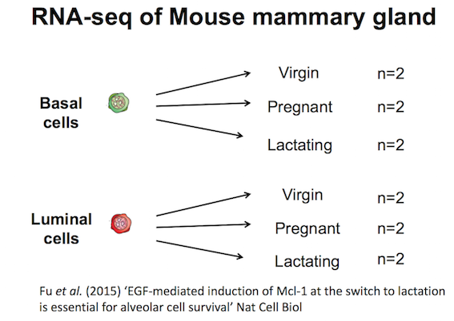

## Tidyverse package

The `tidyverse` package that we installed in section 2 is a collection of R packages that includes the extremely widely used **`ggplot2`** package.

The [tidyverse](https://www.tidyverse.org/) makes data science faster, easier and more fun.

## Load the package

We use `library()` to load in the packages that we need. As described in the cooking analogy in the first screenshot, `install.packages()` is like buying a saucepan, `library()` is taking it out of the cupboard to use it.

**Your turn 3.1:** Load your tidyverse library. If you get an error message, it means that you have not installed it! (see the code in the Section 2).

```r
library(tidyverse)
```

## Load the data

The files we will use are in a format called csv (comma-separated values), so we will use the `read_csv()` function from the tidyverse. There is also a `read_tsv()` function for tab-separated values.

**Your turn 3.2:** Download the data.zip file [here](https://melbintgen.github.io/intro-to-r/data.zip). Unzip the file and **store the content in the `data` folder in your working directory**.

We will use the counts file called `GSE60450_GeneLevel_Normalized(CPM.and.TMM)_data.csv` stored in the data folder. The path to the file should be `data/GSE60450_GeneLevel_Normalized(CPM.and.TMM)_data.csv`.

**Your turn 3.3:** Load the count data into your R working directory. We will store the contents of the counts file in an **object** called `counts`.

```r
# read in counts file
counts <- read_csv("data/GSE60450_GeneLevel_Normalized(CPM.and.TMM)_data.csv")
```

```
## ──────────────────────────────────────────────────────── Delimiter: "," chr
## (2): ...1, gene_symbol dbl (12): GSM1480291, GSM1480292, GSM1480293,
## GSM1480294, GSM1480295, GSM148...
```

No need to be overwhelmed by the outputs! It contains information regarding “column specification” (telling us that there is a missing column name in the header and it has been filled with the name “…1”, which is how read_csv handles missing column names by default). We will fix this later. It also tells us what data types `read_csv` is detecting in each column. Columns with text characters have been detected (`col_character`) and also columns with numbers (`col_double`). We won’t get into the details of R data types in this tutorial but they are important to know when you get more proficient in R. You can read more about them in the [R for Data Science book](https://r4ds.had.co.nz/vectors.html#important-types-of-atomic-vector).

**Your turn 3.4:** Load the sample information data into your R working directory. We will store the contents of this file in an object called `sampleinfo`.

```r
# read in metadata
sampleinfo <- read_csv("data/GSE60450_filtered_metadata.csv")
```

```
## ──────────────────────────────────────────────────────── Delimiter: "," chr
## (4): ...1, characteristics, immunophenotype, developmental stage
```

It is very common when looking at biological data that you have two types of data. One is the actual data (in this case, our `counts` object, which has the expression values of different genes in each sample). The other is **metadata** i.e. information about our samples (in this case, our `sampleinfo` object includes information about whether samples are from basal or luminal cells and whether the cells were from mice which are virgin/pregnant/lactating, etc.)

**What data have we imported into R?** To summarise, we have imported two dataframes (i.e. tables) into R:

- `counts` object is our gene expression data
- `sampleinfo` object is our sample metadata

# 4. Looking at the data

When assigning a value to an object, R does not print the value. We do not see what is in `counts` or `sampleinfo`. But there are ways we can look at the data.

**Your turn 4.1:** Option 1: Click on the `counts` object in your global environment panel on the right-hand-side of RStudio. It will open a new Tab.

**Your turn 4.2:** Option 2: type the name of the object and this will print the first few lines and some information, such as number of rows. Note that this is similar to how we looked at the value of objects we assigned in section 1.

```r
counts
```

| ...1 | gene_symbol | GSM1480291 | GSM1480292 | GSM1480293 | GSM1480294 | GSM1480295 | GSM1480296 | GSM1480297 | GSM1480298 | GSM1480299 | GSM1480300 | GSM1480301 | GSM1480302 |
| --- | --- | --- | --- | --- | --- | --- | --- | --- | --- | --- | --- | --- | --- |
| ENSMUSG00000000001 | Gnai3 | 243.28596 | 255.66037 | 239.73819 | 217.10047 | 84.74389 | 84.59855 | 175.03566 | 187.48789 | 176.66285 | 169.09410 | 158.44710 | 133.59160 |
| ENSMUSG00000000003 | Pbsn | 0.00000 | 0.00000 | 0.00000 | 0.00000 | 0.00000 | 0.00000 | 0.00000 | 0.00000 | 0.00000 | 0.00000 | 0.00000 | 0.00000 |
| ENSMUSG00000000028 | Cdc45 | 11.18453 | 13.78314 | 11.60091 | 4.27180 | 8.35011 | 8.19949 | 12.10863 | 11.09874 | 7.53319 | 7.09890 | 1.98114 | 2.88361 |
| ENSMUSG00000000031 | H19 | 6.30808 | 8.53042 | 7.09408 | 11.03901 | 0.19419 | 0.00000 | 2.11801 | 1.19067 | 1.54527 | 0.86673 | 10.83023 | 5.76722 |
| ENSMUSG00000000037 | Scml2 | 2.19217 | 4.66442 | 2.79590 | 2.49541 | 1.24281 | 0.85492 | 5.79456 | 8.80245 | 9.81246 | 7.47035 | 7.57235 | 9.87992 |
| ENSMUSG00000000049 | Apoh | 0.22369 | 0.08404 | 0.00000 | 0.00000 | 0.00000 | 0.00000 | 0.19981 | 0.17010 | 0.03863 | 0.04127 | 0.26415 | 0.04727 |
| ENSMUSG00000000056 | Narf | 11.27401 | 14.74964 | 26.16464 | 18.82130 | 14.71949 | 13.91193 | 30.65122 | 21.68719 | 18.31143 | 9.03871 | 18.62271 | 18.53075 |
| ENSMUSG00000000058 | Cav2 | 118.24288 | 112.70235 | 50.53489 | 63.40027 | 186.22683 | 157.84994 | 122.68481 | 116.38792 | 151.39771 | 153.28667 | 209.42841 | 221.04541 |
| ENSMUSG00000000078 | Klf6 | 2036.16657 | 2230.26276 | 1902.63241 | 1959.61407 | 1094.01954 | 1096.16718 | 903.15201 | 890.83323 | 1017.86852 | 997.39516 | 1741.68536 | 1958.44535 |
| ENSMUSG00000000085 | Scmh1 | 33.68781 | 38.70204 | 9.18057 | 9.43180 | 3.92261 | 3.26425 | 40.60188 | 47.54172 | 36.66150 | 36.27867 | 49.26432 | 62.68311 |

[output cut: 9990 more lines]

We can also take a look the first few lines with `head()`. This shows us the first 6 lines.

**Your turn 4.3:** Use `head()` to look at the first few lines of `counts`.

```r
head(counts)
```

| ...1 | gene_symbol | GSM1480291 | GSM1480292 | GSM1480293 | GSM1480294 | GSM1480295 | GSM1480296 | GSM1480297 | GSM1480298 | GSM1480299 | GSM1480300 | GSM1480301 | GSM1480302 |
| --- | --- | --- | --- | --- | --- | --- | --- | --- | --- | --- | --- | --- | --- |
| ENSMUSG00000000001 | Gnai3 | 243.28596 | 255.66037 | 239.73819 | 217.10047 | 84.74389 | 84.59855 | 175.03566 | 187.48789 | 176.66285 | 169.09410 | 158.44710 | 133.59160 |
| ENSMUSG00000000003 | Pbsn | 0.00000 | 0.00000 | 0.00000 | 0.00000 | 0.00000 | 0.00000 | 0.00000 | 0.00000 | 0.00000 | 0.00000 | 0.00000 | 0.00000 |
| ENSMUSG00000000028 | Cdc45 | 11.18453 | 13.78314 | 11.60091 | 4.27180 | 8.35011 | 8.19949 | 12.10863 | 11.09874 | 7.53319 | 7.09890 | 1.98114 | 2.88361 |
| ENSMUSG00000000031 | H19 | 6.30808 | 8.53042 | 7.09408 | 11.03901 | 0.19419 | 0.00000 | 2.11801 | 1.19067 | 1.54527 | 0.86673 | 10.83023 | 5.76722 |
| ENSMUSG00000000037 | Scml2 | 2.19217 | 4.66442 | 2.79590 | 2.49541 | 1.24281 | 0.85492 | 5.79456 | 8.80245 | 9.81246 | 7.47035 | 7.57235 | 9.87992 |
| ENSMUSG00000000049 | Apoh | 0.22369 | 0.08404 | 0.00000 | 0.00000 | 0.00000 | 0.00000 | 0.19981 | 0.17010 | 0.03863 | 0.04127 | 0.26415 | 0.04727 |

We can look at the last few lines with `tail()`. This shows us the last 6 lines. This can be useful to check the bottom of the file, that it looks ok.

**Your turn 4.4:** Use `tail()` to look at the last few lines of `counts`.

```r
tail(counts)
```

| ...1 | gene_symbol | GSM1480291 | GSM1480292 | GSM1480293 | GSM1480294 | GSM1480295 | GSM1480296 | GSM1480297 | GSM1480298 | GSM1480299 | GSM1480300 | GSM1480301 | GSM1480302 |
| --- | --- | --- | --- | --- | --- | --- | --- | --- | --- | --- | --- | --- | --- |
| ENSMUSG00000104318 | Pcdha7 | 0.13421 | 0.00000 | 0.00000 | 0.00000 | 0.00000 | 0.00000 | 0.11989 | 0.00000 | 0.00000 | 0.08255 | 0.00000 | 0.00000 |
| ENSMUSG00000104336 | Gm34240 | 0.00000 | 0.00000 | 0.00000 | 0.00000 | 0.00000 | 0.03886 | 0.00000 | 0.00000 | 0.00000 | 0.00000 | 0.00000 | 0.00000 |
| ENSMUSG00000104346 | Pcdhga3 | 0.58160 | 2.26917 | 0.33384 | 1.09967 | 0.00000 | 0.15544 | 0.75929 | 1.87105 | 2.08611 | 1.52709 | 1.32076 | 1.41817 |
| ENSMUSG00000104401 | Gm20750 | 0.00000 | 0.08404 | 0.04173 | 0.00000 | 0.00000 | 0.00000 | 0.07992 | 0.12757 | 0.00000 | 0.00000 | 0.04403 | 0.14182 |
| ENSMUSG00000104445 | Rhbg | 5.27910 | 4.95857 | 6.25948 | 3.97573 | 1.00978 | 0.62176 | 0.87917 | 0.34019 | 1.23621 | 1.15563 | 0.35220 | 0.28363 |
| ENSMUSG00000104463 | Mat2a | 212.19296 | 224.85842 | 97.94004 | 70.08289 | 22.02098 | 26.77465 | 256.83885 | 311.87030 | 209.53844 | 200.79150 | 194.94408 | 155.76233 |

**Your turn 4.5:** What are the cell type of the first 6 samples in the metadata for the Fu et al. 2015 experiment?

## Dimension of the data

You can print the number of rows and columns using the function `dim()`.

For example,

```r
dim(sampleinfo)
```

```
## [1] 12  4
```

`sampleinfo` has 12 rows, correponding to our 12 samples, and 4 columns, corresponding to different bits of data about the samples.

**✔️ Tip: Always Verify Your Data Size**

Double-check that your data has the expected number of rows and columns. It’s easy to read the wrong file or encounter corrupted downloads. Catching these issues early will save you a lot of trouble later!

**Your turn 4.6:** Check how many rows and columns are in `counts`. Do these numbers match what we expected?

## Column and row names of the data

**Your turn 4.7:** Check the column and row names used in in `sampleinfo`. Comment on the results you get.

```r
colnames(sampleinfo)
rownames(sampleinfo)
```

## The `$` symbol

We can access individual columns by name using the `$` symbol.

**Your turn 4.8:** Extract the ‘immunophenotype’ column of the metadata.

```r
sampleinfo$immunophenotype
```

## Subsetting

Subsetting is very useful tool in R which allows you to extract parts of the data you want to analyse. In R, a data set has the form of a matrix with rows and columns. You can access these rows or columns by using square brackets `[ ]`.

For example, we can extract the first row ‘1’ of the data, using the number on the *left-hand-side* of the comma.

**Your turn 4.9:** Extract the first row using square brackets.

```r
sampleinfo[1,]
```

Here we extract the second column ‘2’ of the data, as indicated on the *right-hand-side* of the comma.

**Your turn 4.10:** Extract the second column using square brackets.

```r
sampleinfo[,2]
```

You can use a combination of number of row and column to extract one element in the matrix.

**Your turn 4.11:** Extract the element in the first row and second column.

```r
sampleinfo[1,2]
```

**Your turn 4.12:** Work out what the following commands mean, then use one of them to subset `sampleinfo` so you extract the first 3 rows:

```r
1:3
c(1, 3)
```

**ⓘ The c() function**

We use the `c()` function extremely often in R when we have multiple items that we are *combining* (‘c’ stands for concatenating). We will see it again in this tutorial.

In the previous section, when we loaded in the data from the csv file, we noticed that the first column had a missing column name and by default, the `read_csv` function assigned a name of `"\...1"` to it. We can change this column to something more descriptive by combining what what we have learnt.

**Your turn 4.13:** Describe what the next command line is doing:

```r
colnames(sampleinfo)[1] <- "sample_id"
# check
sampleinfo
```

| sample_id | characteristics | immunophenotype | developmental stage |
| --- | --- | --- | --- |
| GSM1480291 | mammary gland, luminal cells, virgin | luminal cell population | virgin |
| GSM1480292 | mammary gland, luminal cells, virgin | luminal cell population | virgin |
| GSM1480293 | mammary gland, luminal cells, 18.5 day pregnancy | luminal cell population | 18.5 day pregnancy |
| GSM1480294 | mammary gland, luminal cells, 18.5 day pregnancy | luminal cell population | 18.5 day pregnancy |
| GSM1480295 | mammary gland, luminal cells, 2 day lactation | luminal cell population | 2 day lactation |
| GSM1480296 | mammary gland, luminal cells, 2 day lactation | luminal cell population | 2 day lactation |
| GSM1480297 | mammary gland, basal cells, virgin | basal cell population | virgin |
| GSM1480298 | mammary gland, basal cells, virgin | basal cell population | virgin |
| GSM1480299 | mammary gland, basal cells, 18.5 day pregnancy | basal cell population | 18.5 day pregnancy |
| GSM1480300 | mammary gland, basal cells, 18.5 day pregnancy | basal cell population | 18.5 day pregnancy |

[output cut: 2 more lines]

**Your turn 4.14:** Do the same to rename the first column name from “...1” to “gene_id” in the `counts` object.

## Other useful commands: `str` and `summary`

`str()` shows us the structure of our data. It shows us what columns there are, the first few entries, and what data type they are e.g. character or numbers (double or integer).

**Your turn 4.15:** Show the structure of the metadata

```r
str(sampleinfo)
```

`summary()` generates summary statistics of our data. For numeric columns (columns of type double or integer) it outputs statistics such as the min, max, mean and median. We will demonstrate this with the counts file as it contains numeric data. For character columns it shows us the length (how many rows).

**Your turn 4.16:** Generate summary statistics for the count data

```r
summary(counts)
```

# 5. Formatting data

## Converting from wide to long format

We will first convert the data from wide format into long format to make it easier to work with and so that we can plot the data with the `ggplot` package.

Instead of multiple columns with counts for each sample, we just want one column containing all the expression values, as shown below:

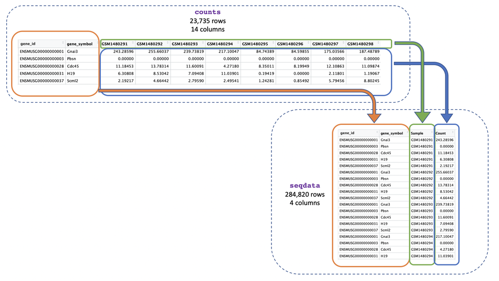

We can use `pivot_longer()` to easily change the format into long format.

**Your turn 5.1:** Find out what `pivot_longer()` does and how to use it

```r
?pivot_longer
```

**Your turn 5.2:** Convert the counts data into long format and save it as a new object called `seqdata`

```r
seqdata <- pivot_longer(counts, cols = starts_with("GSM"),
                        names_to = "Sample", values_to = "Count")
```

*Explanation*: We use `cols = starts_with("GSM")` to tell the function we want to reformat the columns whose names start with “GSM” (these columns are the ones where we have the gene counts). `pivot_longer()` will then reformat the specified columns into two new columns, which we’re naming “Sample” and “Count”. The`names_to = "Sample"` specifies that we want the new column containing the columns to be named “Sample”, and the`values_to = "Count"` specifies that we want the new column containing the values to be named “Count”.

As explained earlier, in R there is often more than one way to do the same thing. We could get the same result by specifying the argument `cols` in a different way. For example, instead of using `starts_with` we could use a range like the one you used in question 4.12.

**Your turn 5.3:** Convert the counts data into long format using a column range

```r
seqdata <- pivot_longer(counts, cols = GSM1480291:GSM1480302,
                        names_to = "Sample", values_to = "Count")
```

Another way we could do the same thing is by specifying the columns we *do not* want to reformat, this will tell `pivot_longer()` to reformat all the other columns. To do that we put **a minus sign “-”** in front of the column names that we don’t want to reformat. This is a pretty common way to use `pivot_longer()` as sometimes it is easier to exclude columns we don’t want than include columns we do. The command below would give us the same result as the previous command.

**Your turn 5.4:** Convert the counts data into long format by specifying which columns not to convert

```r
seqdata <- pivot_longer(counts, cols = -c("gene_id", "gene_symbol"),
                        names_to = "Sample", values_to = "Count")
```

**Your turn 5.5:** Type each command line above, then look at the data, are all three of the `seqdata` objects you made the same?

## Joining two tables

Now that we’ve got just one column containing sample ids in both our counts and metadata objects we can join them together using the sample ids. This will make it easier to identify the categories for each sample (e.g. if it’s basal cell type) and to use that information in our plots.

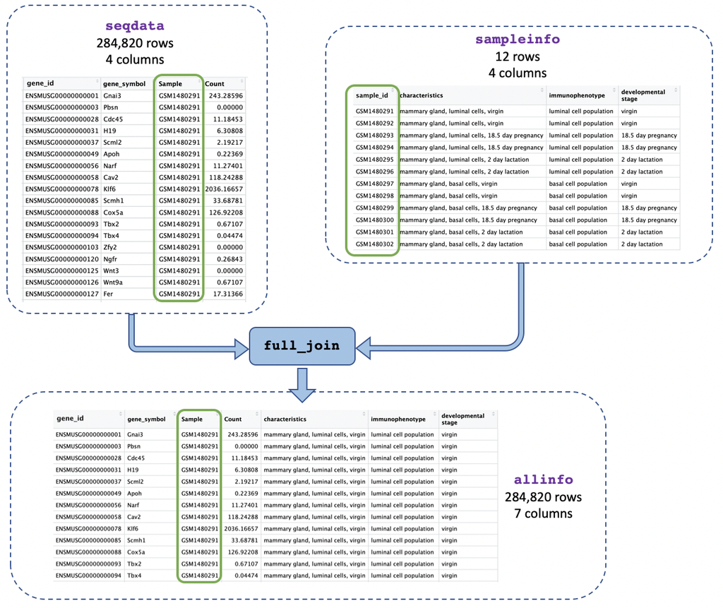

*Explanation:* We use the function `full_join()` and give as arguments the two tables we want to join. We add `by = join_by(Sample == sample_id)` to say we want to join on the column called “Sample” in the first table (`seqdata`) and the column called “sample_id” in the second table (`sampleinfo`) when the values match:

**Your turn 5.6:** Join the count data and metadata by matching sample IDs

```r
allinfo <- full_join(seqdata, sampleinfo, by = join_by(Sample == sample_id))
```

**Your turn 5.7:** Have a look at the new object you generated above and see what information it includes, how many columns does it have and what does each column tell you?

# 6. Plotting with **`ggplot2`**

**`ggplot2`** is a plotting package that makes it simple to create complex plots. One really great advantage compared to classic R packages is that we only need to make minimal changes if the underlying data change or if we decide to change our plot type, for example, from a box plot to a violin plot. This helps in creating publication quality plots with minimal amounts of adjustments and tweaking.

**`ggplot2`** likes data in the ‘long’ format, i.e., a column for every variable, and a row for every observation, similar to what we created with `pivot_longer()` above. Well-structured data will save you lots of time when making figures with **`ggplot2`**.

**📊 Understanding ggplot2 Architecture**

ggplot2 plots are built step by step by adding layers with `+`. This approach provides great flexibility, allowing you to customize your plots extensively.

To build a ggplot, we use the following basic template that can be used for different types of plots. Three things are required for a ggplot:

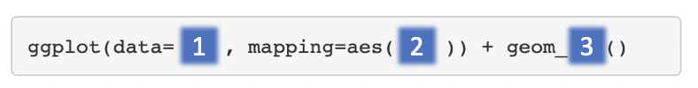

1. The data
2. The columns in the data we want to map to visual properties (called aesthetics or `aes`) e.g. the columns for x values, y values and colours
3. The type of plot (the `geom_`)

There are different geoms we can use to create different types of plot e.g. `geom_line()` `geom_point()`, `geom_boxplot()`. To see the geoms available take a look at the ggplot2 help or the handy [ggplot2 cheatsheet](https://rstudio.github.io/cheatsheets/data-visualization.pdf). Or if you type “geom” in RStudio, RStudio will show you the different types of geoms you can use.

## Creating a boxplot

Let’s plot boxplots to visualise the distribution of the counts for each sample. This helps us to compare the samples and check if any look unusual.

*Note: with ggplot the “+” must go at the end of the line, it can’t go at the beginning.*

**Your turn 6.1:** Run the following command line. Identify the key functions `aes` and type of plot:

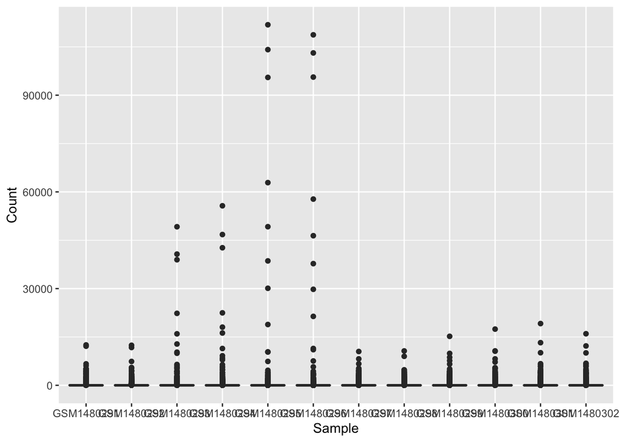

```r
ggplot(data = allinfo, mapping = aes(x = Sample, y = Count)) +
  geom_boxplot()
```

This plot looks a bit weird. It’s because we have some genes with extremely high counts. To make it easier to visualise the distributions we usually plot the logarithm of RNA-seq counts. We’ll plot the Sample on the X axis and log~ 2~ Counts on the y axis. We can log the Counts within the `aes()`. The sample labels are also overlapping each other, we will show how to fix this later.

**Your turn 6.2:** Generate a boxplot of log2 gene counts

```
## Warning: Removed 84054 rows containing non-finite outside the scale range
## (`stat_boxplot()`).
```

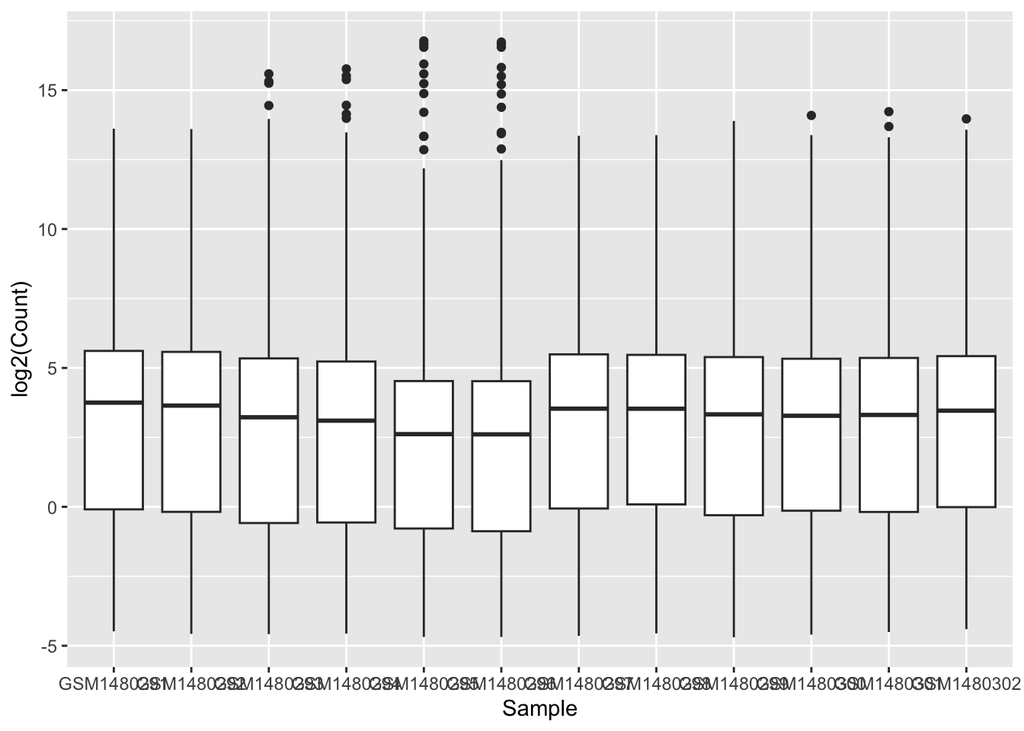

```r
ggplot(data = allinfo, mapping = aes(x = Sample, y = log2(Count))) +
  geom_boxplot()
```

We get a warning here about rows containing non-finite values being removed. This is because some of the genes have a count of zero in the samples and a log of zero is undefined. We can add +1 to every count to avoid the zeros being dropped (‘psuedo-count’).

**Your turn 6.3:** Generate a boxplot of log2 gene counts + 1

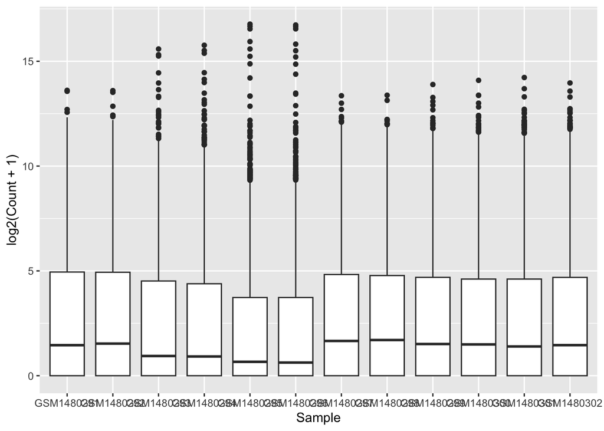

```r
ggplot(data = allinfo, mapping = aes(x = Sample, y = log2(Count + 1))) +
  geom_boxplot()
```

The box plots show that the distributions of the samples are not identical but they are not very different.

## Violin plot

Boxplots are useful summaries, but hide the shape of the distribution. For example, if the distribution is bimodal, we would not see it in a boxplot. An alternative to the boxplot is the **violin plot**, where the shape (of the density of points) is drawn.

Let’s choose a different geom to do another type of plot.

**Your turn 6.4:** Using the same data (same x and y values), try editing the code above to make a violin plot using the `geom_violin()` function.

## Colouring by categories

Let’s add a different colour for each sample.

**Your turn 6.5:** Get the help file for `geom_boxplot` and scroll down to **Aesthetics** heading. It specifies that there is an option for colour.

**Your turn 6.6:** Map each sample to a colour using the `colour =` argument. As we are mapping colour to a column in our data we need toput this inside `aes()`.

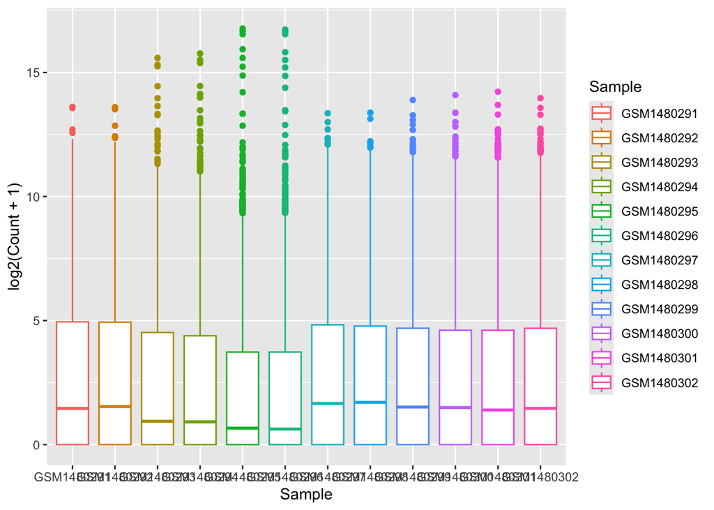

```r
ggplot(data = allinfo, mapping = aes(x = Sample, y = log2(Count + 1), colour = Sample)) +
  geom_boxplot()
```

Colouring the edges wasn’t quite what we had in mind. Look at the help for `geom_boxplot` to see what other aesthetic we could use. Let’s try `fill =` instead.

**Your turn 6.7:** Map each sample to a colour using the `fill =` argument.

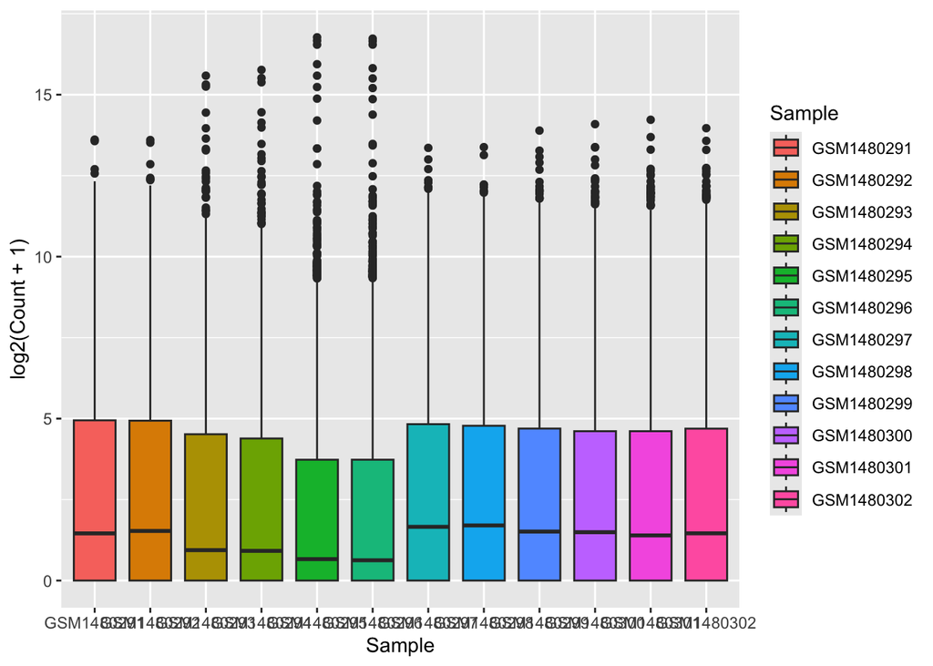

```r
ggplot(data = allinfo, mapping = aes(x = Sample, y = log2(Count + 1), fill = Sample)) +
  geom_boxplot()
```

That looks better. `fill =` is used to fill in areas in ggplot2 plots, whereas `colour =` is used to colour lines and points.

A really nice feature about ggplot is that we can easily colour by another variable by simply changing the column we give to `fill =`.

## Creating subplots for each gene using faceting

With ggplot we can easily make subplots using *faceting*. For example we can make [stripcharts](http://www.sthda.com/english/wiki/ggplot2-stripchart-jitter-quick-start-guide-r-software-and-data-visualization). These are a type of scatterplot and are useful when there are a small number of samples (when there are not too many points to visualise). Here we will make stripcharts plotting expression by the groups (basal virgin, basal pregnant, basal lactating, luminal virgin, luminal pregnant, luminal lactating) for each gene.

### Shorter category names

As we saw in question 5.5, our column names are quite long, and this might make them difficult to visualise on a plot. We can use the function `mutate()` to add another column to our `allinfo` object with shorter group names.

**Your turn 6.8:** Make a new column in `allinfo` with shortened category names using the below code. How has the object `allinfo` changed?

```r
allinfo <- mutate(allinfo, Group = case_when(
        str_detect(characteristics, "basal.*virgin") ~  "bvirg",
        str_detect(characteristics, "basal.*preg")  ~  "bpreg",
        str_detect(characteristics, "basal.*lact")  ~  "blact",
        str_detect(characteristics, "luminal.*virgin")  ~  "lvirg",
        str_detect(characteristics, "luminal.*preg")  ~  "lpreg",
        str_detect(characteristics, "luminal.*lact")  ~  "llact"
       ))
```

### Filter for genes of interest

**Your turn 6.9:** How many genes are there in our data?

Like our data set, most RNA-seq data sets have information on thousands of genes, but most of them are usually not very interesting, so we may want to filter them.

Here, we choose 8 genes with the highest counts summed across all samples. They are listed here.

**Your turn 6.10:** Create an object with a list of the 8 most highly expressed genes

```r
mygenes <- c("Csn1s2a", "Csn1s1", "Csn2", "Glycam1", "COX1", "Trf", "Wap", "Eef1a1")
```

We filter our data for just these genes of interest. We use `%in%` to check if a value is in a set of values.

**Your turn 6.11:** Filter the counts data to only include genes in the `mygenes` object

```r
mygenes_counts <- filter(allinfo, gene_symbol %in% mygenes)
```

**Your turn 6.12:** Can you figure out how many rows `mygenes_counts` will have without inspecting the object? Print the dimensions of the object to check if you’re right.

To identify these 8 genes, we used [pipes](https://r4ds.had.co.nz/pipes.html) (`%>%`) to string a series of function calls together (which is beyond the scope of this tutorial, but totally worth learning about independently!).

```
mygenes <- allinfo %>%
  group_by(gene_symbol) %>%
  summarise(Total_count = sum(Count)) %>%
  arrange(desc(Total_count)) %>%
  head(n = 8) %>%
  pull(gene_symbol)
```

### Faceting

**Your turn 6.13:** Make boxplots faceted by gene, grouped and coloured by groups

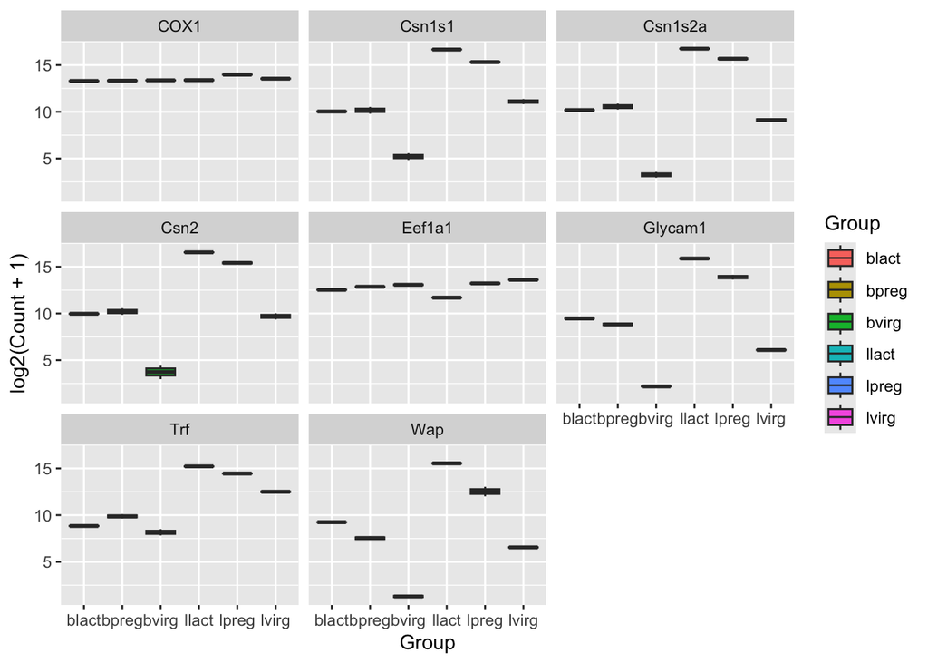

```r
ggplot(data = mygenes_counts,
       mapping = aes(x = Group, y = log2(Count + 1), fill = Group)) +
  geom_boxplot() +
  facet_wrap(~ gene_symbol)
```

*Explanation*: We *facet* on the `gene_symbol` column using `facet_wrap()`. We add the tilde symbol `~` in front of the column we want to facet on.

## Scatterplots

In the example over, boxplots are not suitable because we only have two values per group. Let’s plot the individual points instead using the `geom_point()` to make a scatter plot.

**Your turn 6.14:** Make scatter plots faceted by gene and grouped by groups

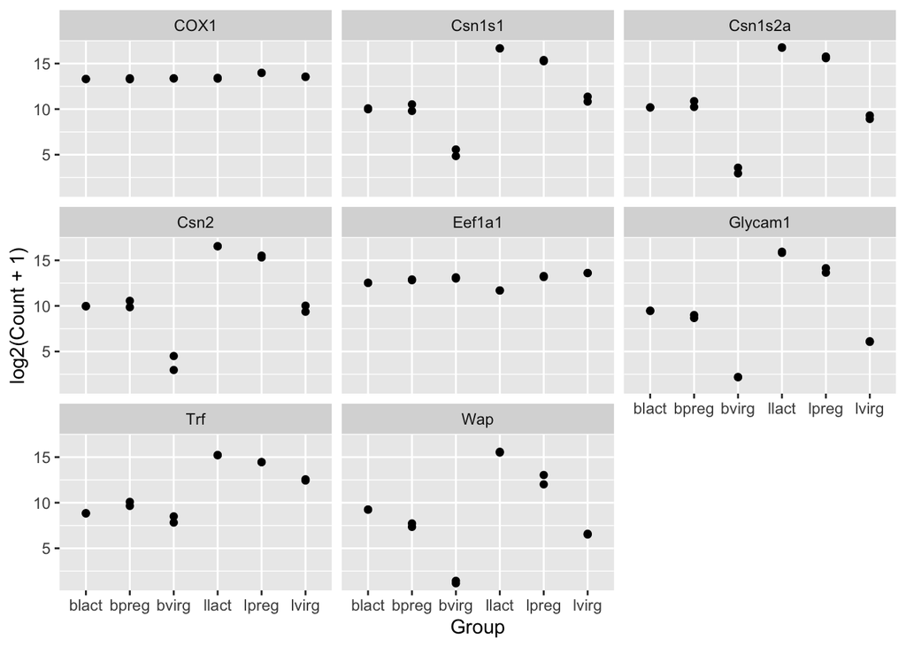

```r
ggplot(data = mygenes_counts, mapping = aes(x = Group, y = log2(Count + 1))) +
  geom_point() +
  facet_wrap(~ gene_symbol)
```

### Jitter plot

In the previous plots, the points are overlapping which makes it hard to see them. We can make a jitter plot using `geom_jitter()` which adds a small amount of random variation to the location of each point so they do not overlap. If is also quite common to combine jitter plots with other types of plot, for example, [jitter with boxplot](https://simplystatistics.org/2019/02/21/dynamite-plots-must-die/).

**Your turn 6.15:** Make jitter plots faceted by gene and grouped by groups

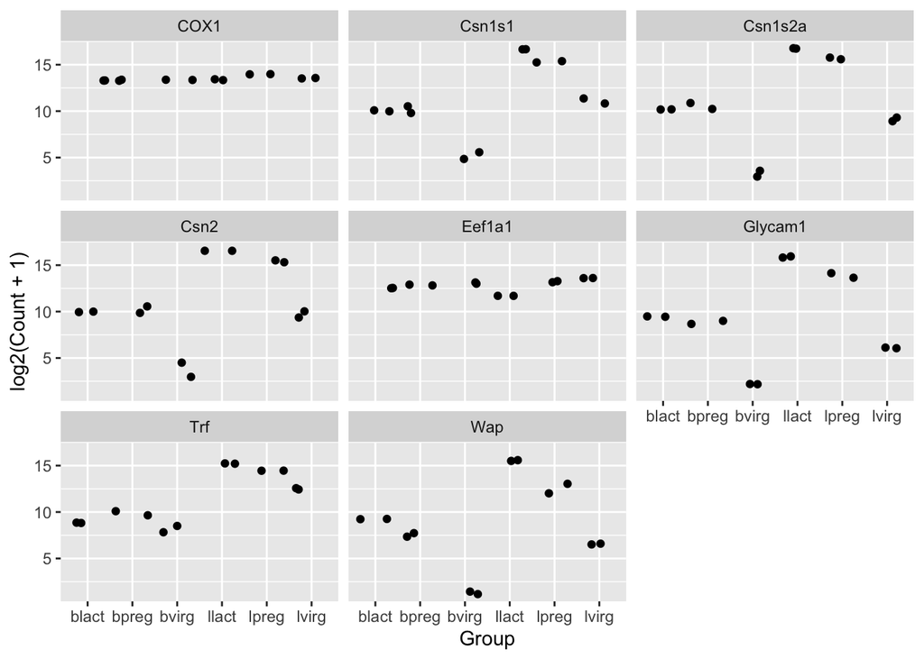

```r
ggplot(data = mygenes_counts, mapping = aes(x = Group, y = log2(Count + 1))) +
  geom_jitter() +
  facet_wrap(~ gene_symbol)
```

**Your turn 6.16:** Modify the code above to colour the jitter plots by group

# 7. Saving plots

We can save plots interactively by clicking Export in the Plots window and saving as e.g. “myplot.pdf”. Or we can output plots to pdf using `pdf()` followed by `dev.off()`. We put our plot code after the call to `pdf()` and before closing the plot device with `dev.off()`.

**Your turn 7.1:** Let’s save our last plot.

```r
pdf("myplot.pdf")
ggplot(data = mygenes_counts,
       mapping = aes(x = Group, y = log2(Count + 1), colour = Group)) +
  geom_jitter() +
  facet_wrap(~ gene_symbol)
dev.off()
```

# 8. Main exercises

Choose one of the two following exercise, or use your own data to practice how to input them into R and make a few plots (exercise 1).

## Exercise 1: plotting

Here we will work on the RNA-seq data from Fu et al. However, feel free to upload your own data instead and apply your new learning!

1. The raw counts for the RNA-seq data are available in the data folder with the name ‘GSE60450_GeneLevel_Raw_data.csv’.
1. Plot a boxplot. Do the samples look any different to the normalised counts?
2. Make subplots using jitter plots for the same set of 8 genes. Do they look any different to the normalised counts?
2. The normalised counts for another data set ‘GSE63310_GeneLvel_Normalized(CPM.an.TMM)_data.csv’ are also available. Make 2 boxplots, one colouring the samples by strain/background and one colouring them by age.

## Exercise 2: reading data, cleaning and reformatting

This exercise is useful to apply your learnings on how to wrangle data (a step that is often overlooked but takes a long time!)

1. We will look at the ‘breast_tumors.csv’, ‘gene_description.txt’ and ‘gene_name.xlsx’ data files, then read each file using one of the appropriate function `read_csv()`, `read_tsv()` or `read_excel()` (from the package `readxl`). Name each file appropriately. *Note: you will need to load the package `readxl` first.
2. Extract the treatment variable from breast_tumor.csv, inspect and solve issues in this file (hint: there are some labelling inconsistencies).
3. Combine the data from ‘gene_name.xlsx’ and ‘gene_description.txt’

# 9. Session Info

At the end of your report, we recommend you run the `sessionInfo()` function which prints out details about your working environment such as the version of R yo are running, loaded packages, and package versions. Printing out `sessionInfo()` at the end of your analysis is good practice as it helps with reproducibility in the future.

[session information not shown]

# 10. Key Points

- Tabular data can be loaded into R with the tidyverse functions `read_csv()` and `read_tsv()`
- Tidyverse functions such as `pivot_longer()`, `mutate()`, `filter()`, `select()`, `full_join()` can be used to manipulate data
- A ggplot2 plot has 3 components: `data` (dataset), `mapping` (columns to plot) and `geom` (type of plot). Different types of plots include `geom_point()`, `geom_jitter()`, `geom_line()`, `geom_boxplot()`, `geom_violin()`.
- `facet_wrap()` can be used to make subplots of the data
- The aesthetics of a ggplot can be modified, such as colouring by different columns in the dataset, adding labels or changing the background.
- Don’t forget to practice on subsetting, checking the dimension of the data, extracting and amending the names of the rows and columns of your data.

# Further Reading and Helpful Resources

- [A short intro to R and tidyverse](https://pmacdasci.github.io/r-intro-tidyverse/)
- [Top 50 Ggplot Visualisations](http://r-statistics.co/Top50-Ggplot2-Visualizations-MasterList-R-Code.html)
- [R for Data Science](https://r4ds.hadley.nz/)
- [Datacamp](https://www.datacamp.com/courses/free-introduction-to-r)
- [R ladies Sydney](https://rladiessydney.org/courses/ryouwithme/01-basicbasics-1/)
- [Data wrangling cheatsheet](https://www.rstudio.com/wp-content%2Fuploads%2F2015%2F02%2Fdata-wrangling-cheatsheet.pdf%2F)
- [ggplot 2 cheatsheet](https://posit.co/wp-content/uploads/2022/10/data-visualization-1.pdf)
- [Intro to R markdown](https://rmarkdown.rstudio.com/lesson-1.html)

# Extra material: Customising the plot

## Specifying colours

You might want to control plotting colours. To see what colour names are available you can type `colours()`. There is also an [R colours cheatsheet](https://www.nceas.ucsb.edu/~frazier/RSpatialGuides/colorPaletteCheatsheet.pdf) that shows what the colours look like.

```r
mycolours <- c("turquoise", "plum", "tomato", "violet", "steelblue", "chocolate")
```

Then we then add these colours to the plot using a `+` and `scale_colour_manual(values = mycolours)`.

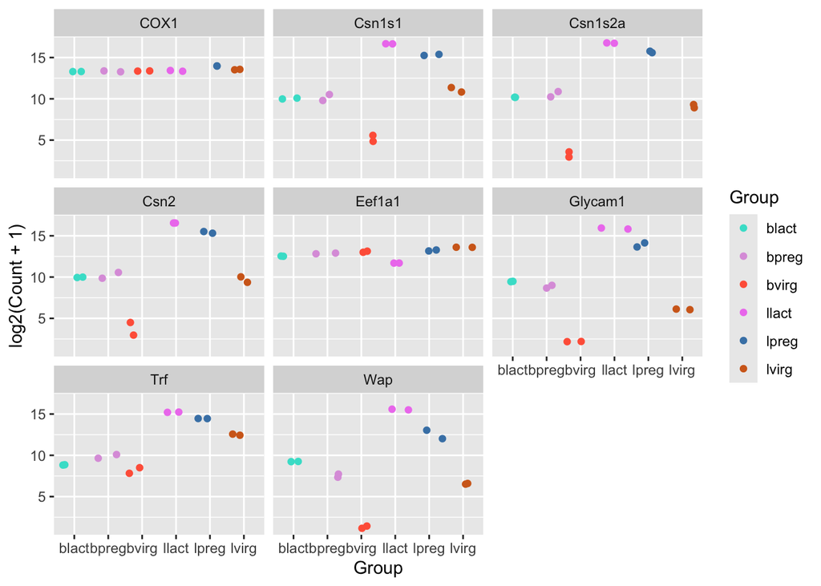

```r
ggplot(data = mygenes_counts,
       mapping = aes(x = Group, y = log2(Count + 1), colour = Group)) +
  geom_jitter() +
  facet_wrap(~ gene_symbol) +
  scale_colour_manual(values = mycolours)
```

There are built-in colour palettes that can be handy to use, where the sets of colours are predefined. `scale_colour_brewer()` is a popular one (there is also `scale_fill_brewer()`). You can take a look at the help for `scale_colour_brewer()` to see what palettes are available. The [R colours cheatsheet](https://www.nceas.ucsb.edu/~frazier/RSpatialGuides/colorPaletteCheatsheet.pdf) also shows what the colours of the palettes look like. There’s one called “Dark2”, let’s have a look at that.

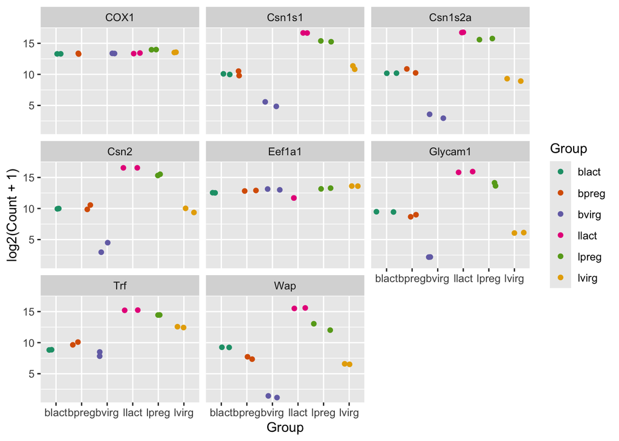

```r
ggplot(data = mygenes_counts,
       mapping = aes(x = Group, y = log2(Count + 1), colour = Group)) +
  geom_jitter() +
  facet_wrap(~ gene_symbol) +
  scale_colour_brewer(palette = "Dark2")
```

## Axis labels and Title

We can change the axis labels and add a title with `labs()`. To change the x axis label we use `labs(x = "New name")`. To change the y axis label we use `labs(y = "New name")` or we can change them all at the same time.

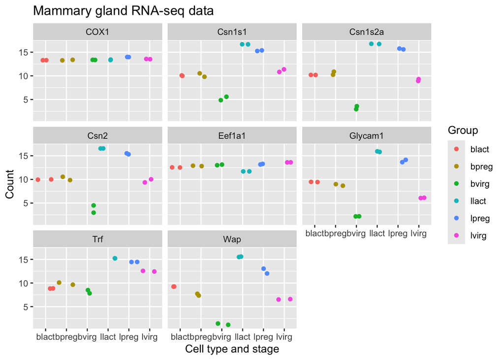

```r
ggplot(data = mygenes_counts,
       mapping = aes(x = Group, y = log2(Count + 1), colour = Group)) +
  geom_jitter() +
  facet_wrap(~ gene_symbol) +
  labs(x = "Cell type and stage", y = "Count", title = "Mammary gland RNA-seq data")
```

## Themes

We can adjust the text on the x axis (the group labels) by turning them 90 degrees so we can read the labels better. To do this we modify the ggplot theme. Themes are the non-data parts of the plot.

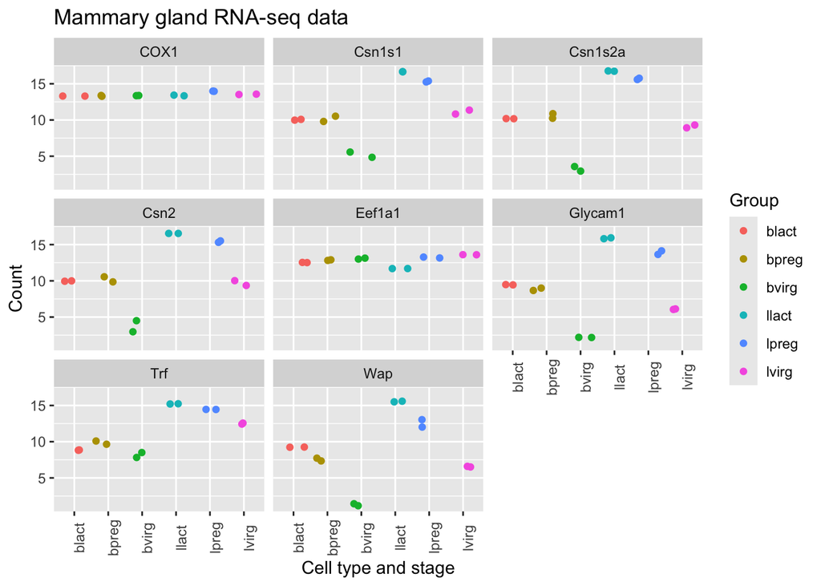

```r
ggplot(data = mygenes_counts,
       mapping = aes(x = Group, y = log2(Count + 1), colour = Group)) +
  geom_jitter() +
  facet_wrap(~ gene_symbol) +
  labs(x = "Cell type and stage", y = "Count", title = "Mammary gland RNA-seq data") +
  theme(axis.text.x = element_text(angle = 90))
```

We can remove the grey background and grid lines.

There are also a lot of built-in themes. Let’s have a look at a couple of the more widely used themes. The default ggplot theme is `theme_grey().`

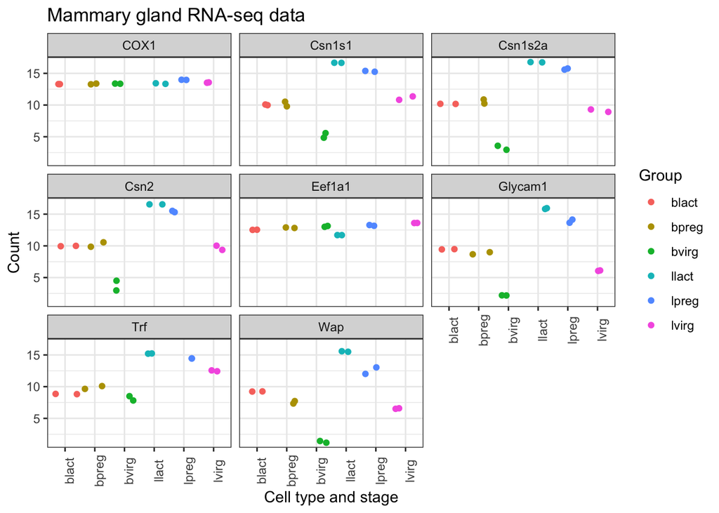

```r
ggplot(data = mygenes_counts,
       mapping = aes(x = Group, y = log2(Count + 1), colour = Group)) +
  geom_jitter() +
  facet_wrap(~ gene_symbol) +
  labs(x = "Cell type and stage", y = "Count", title = "Mammary gland RNA-seq data") +
  theme_bw() +
  theme(axis.text.x = element_text(angle = 90))
```

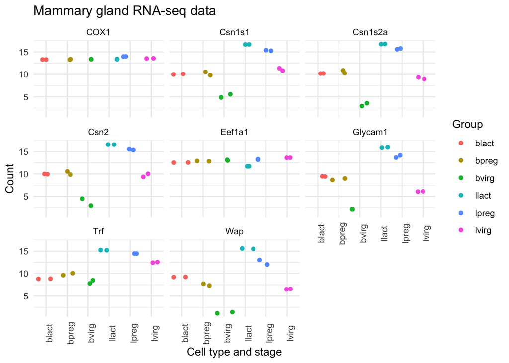

```r
ggplot(data = mygenes_counts,
       mapping = aes(x = Group, y = log2(Count + 1), colour = Group)) +
  geom_jitter() +
  facet_wrap(~ gene_symbol) +
  labs(x = "Cell type and stage", y = "Count", title = "Mammary gland RNA-seq data") +
  theme_minimal() +
  theme(axis.text.x = element_text(angle = 90))
```

There are many themes available, you can see some in the [R graph gallery](https://www.r-graph-gallery.com/192-ggplot-themes/).

We can also modify parts of the theme individually. We can remove the grey background and grid lines with the code below.

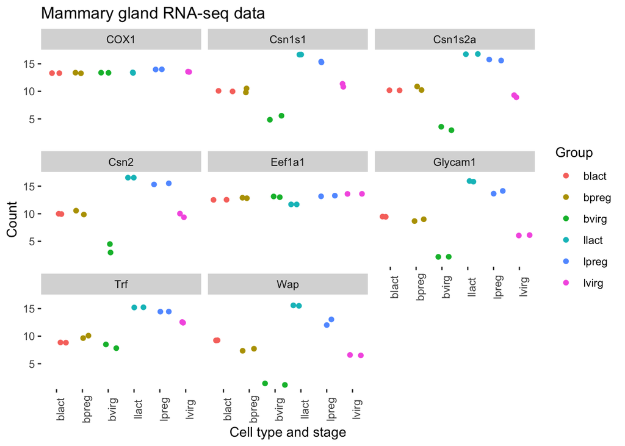

```r
ggplot(data = mygenes_counts,
       mapping = aes(x = Group, y = log2(Count + 1), colour = Group)) +
  geom_jitter() +
  facet_wrap(~ gene_symbol) +
  labs(x = "Cell type and stage", y = "Count", title = "Mammary gland RNA-seq data") +
  theme(axis.text.x = element_text(angle = 90)) +
  theme(panel.background = element_blank(),
        panel.grid.major = element_blank(),
        panel.grid.minor = element_blank())
```

## Order of categories

The groups have been plotted in alphabetical order on the x axis and in the legend (that is the default order), however, we may want to change the order. We may prefer to plot the groups in order of stage, for example, basal virgin, basal pregnant, basal lactate, luminal virgin, luminal pregnant, luminal lactate.

First let’s make an object with the group order that we want.

```r
group_order <- c("bvirg", "bpreg", "blact", "lvirg", "lpreg", "llact")
```

Next we need to make a column with the groups into an R data type called a **factor**. Factors in R are a special data type used to specify categories, you can read more about them in the [R for Data Science book](https://r4ds.had.co.nz/vectors.html#augmented-vectors). The names of the categories are called the factor **levels**.

We’ll add another column called “Group_f” where we’ll make the Group column into a factor and specify what order we want the levels of the factor.

```r
mygenes_counts <- mutate(mygenes_counts, Group_f = factor(Group, levels = group_order))
```

Take a look at the data. As the table is quite wide we can use `select()` to select just the columns we want to view.

```r
select(mygenes_counts, gene_id, Group, Group_f)
```

| gene_id | Group | Group_f |
| --- | --- | --- |
| ENSMUSG00000000381 | lvirg | lvirg |
| ENSMUSG00000000381 | lvirg | lvirg |
| ENSMUSG00000000381 | lpreg | lpreg |
| ENSMUSG00000000381 | lpreg | lpreg |
| ENSMUSG00000000381 | llact | llact |
| ENSMUSG00000000381 | llact | llact |
| ENSMUSG00000000381 | bvirg | bvirg |
| ENSMUSG00000000381 | bvirg | bvirg |
| ENSMUSG00000000381 | bpreg | bpreg |
| ENSMUSG00000000381 | bpreg | bpreg |

[output cut: 86 more lines]

Notice that the Group column has `<chr>` under the heading, that indicates is a character data type, while the Group_f column has `<fct>` under the heading, indicating it is a factor data type. The `str()` command that we saw previously is useful to check the data types in objects.

```r
str(mygenes_counts)
```

```
## tibble [96 × 9] (S3: tbl_df/tbl/data.frame)
##  $ gene_id            : chr [1:96] "ENSMUSG00000000381" "ENSMUSG00000000381" "ENSMUSG00000000381" "ENSMUSG00000000381" ...
##  $ gene_symbol        : chr [1:96] "Wap" "Wap" "Wap" "Wap" ...
##  $ Sample             : chr [1:96] "GSM1480291" "GSM1480292" "GSM1480293" "GSM1480294" ...
##  $ Count              : num [1:96] 90.2 95.6 4140.3 8414.4 49204.9 ...
##  $ characteristics    : chr [1:96] "mammary gland, luminal cells, virgin" "mammary gland, luminal cells, virgin" "mammary gland, luminal cells, 18.5 day pregnancy" "mammary gland, luminal cells, 18.5 day pregnancy" ...
##  $ immunophenotype    : chr [1:96] "luminal cell population" "luminal cell population" "luminal cell population" "luminal cell population" ...
##  $ developmental stage: chr [1:96] "virgin" "virgin" "18.5 day pregnancy" "18.5 day pregnancy" ...
##  $ Group              : chr [1:96] "lvirg" "lvirg" "lpreg" "lpreg" ...
##  $ Group_f            : Factor w/ 6 levels "bvirg","bpreg",..: 4 4 5 5 6 6 1 1 2 2 ...
```

`str()` shows us Group_f column is a Factor with 6 levels (categories).

We can check the factor levels of a column as below.

```r
levels(mygenes_counts$Group_f)
```

```
## [1] "bvirg" "bpreg" "blact" "lvirg" "lpreg" "llact"
```

The levels are in the order that we want, so we can now change our plot to use the “Group_f” column instead of Group column (change `x =` and `colour =`).

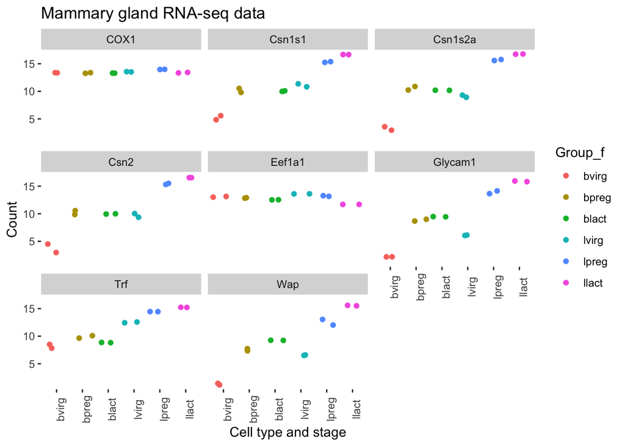

```r
ggplot(data = mygenes_counts,
       mapping = aes(x = Group_f, y = log2(Count + 1), colour = Group_f)) +
  geom_jitter() +
  facet_wrap(~ gene_symbol) +
  labs(x = "Cell type and stage", y = "Count", title = "Mammary gland RNA-seq data") +
  theme(axis.text.x = element_text(angle = 90)) +
  theme(panel.background = element_blank(),
        panel.grid.major = element_blank(),
        panel.grid.minor = element_blank())
```

We could do similar if we wanted to have the genes in the facets in a different order. For example, we could add another column called “gene_symbol_f” where we make the gene_symbol column into a factor, specifying the order of the levels.

#### Exercise

1. Make a colourblind-friendly plot using the colourblind-friendly palettes here.
2. Create a plot (any plot whatsoever) and share it with the class by pasting the image in the Google Docs link provided in your workshop. You plot should use the `subtitle` argument in the `labs` function to add a unique identifier (e.g. a message and your name or initials) which is displayed below the title.

Tip: An easy way to copy your plot in RStudio is using the plot pane’s export option and selecting “Copy to Clipboard…”. You can then paste it into the provided Google document.